# Lab 5

### 2. Calculate the plot and the mean weight for each genus for each year

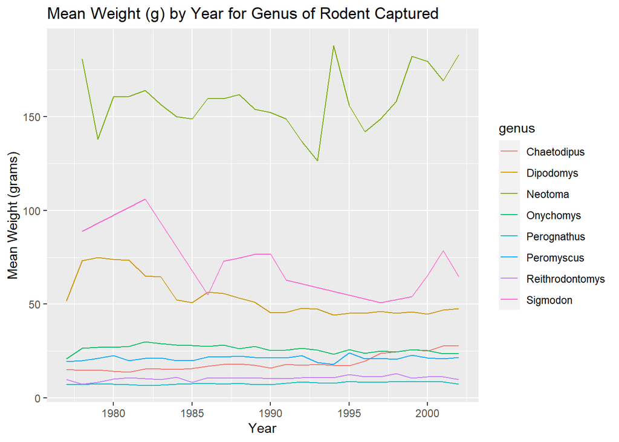

```r
survey_genus <- surveys |>
  group_by(genus, year) |>
  summarize(weight_mean = mean(weight))


ggplot(data = survey_genus,
       mapping = aes(
         x = year,
         y = weight_mean,
         color = genus
         )
       ) +
  geom_line() +
  labs(
    x = "Year",
    y = "Mean Weight (grams)",
    title = "Mean Weight (g) by Year for Genus of Rodent Captured"
  )
```

### 3. Reorder the lines so the mean weights go in descending order (largest to smallest)

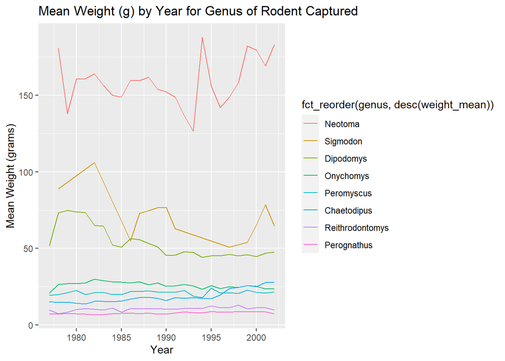

```r
ggplot(data = survey_genus,
       mapping = aes(
         x = year,
         y = weight_mean,
         color = fct_reorder(genus, desc(weight_mean))
         )
       ) +
  geom_line() +
  labs(
    x = "Year",
    y = "Mean Weight (grams)",
    title = "Mean Weight (g) by Year for Genus of Rodent Captured"
    )
```

### 4. Now that you’ve reordered the lines, look at your legend’s label. That’s terrible! Let’s give the legend a new title *and* move the information from the y-axis to the plot title.

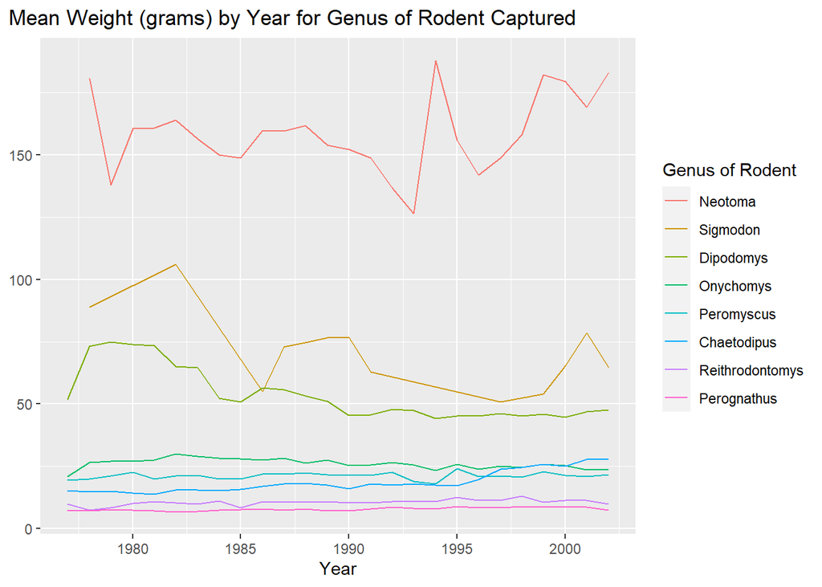

```r
ggplot(data = survey_genus,
       mapping = aes(
         x = year,
         y = weight_mean,
         color = fct_reorder(genus, desc(weight_mean))
         )
       ) +
  geom_line() +
  labs(
    x = "Year",
    y = NULL,
    title = "Mean Weight (grams) by Year for Genus of Rodent Captured",
    color = "Genus of Rodent"
    ) +
  theme(
    plot.title.position = "plot"
  )
```

# 3. Captures over the Week

### 1. Create a visualization of the number of rodents captured each day of the week

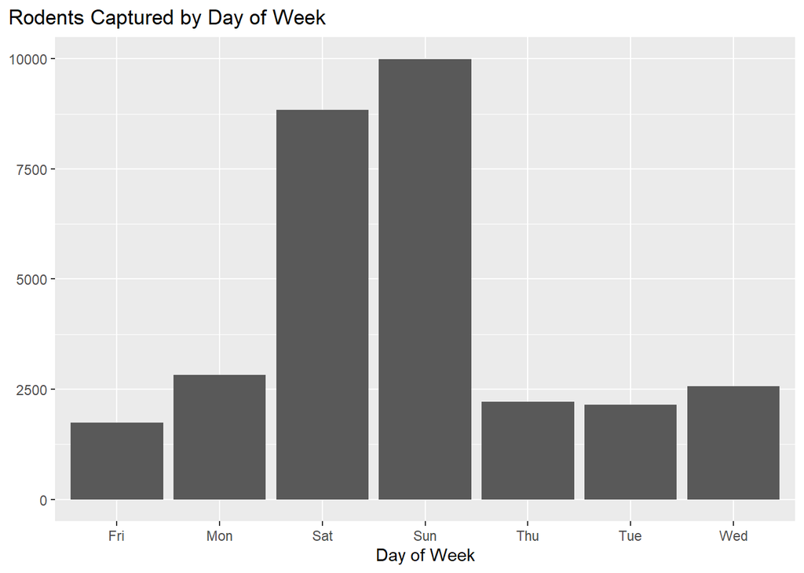

```r
rodents_week <- surveys |>
  group_by(day_of_week) |>
  summarize(rodents_captured = n()) |>
  na.omit()

ggplot(data = rodents_week,
       mapping = aes(
         x = day_of_week,
         y = rodents_captured
        )
       ) +
  geom_col() +
  labs(x = "Day of Week",
       y = NULL,
       title = "Rodents Captured by Day of Week"
   ) +
  theme(
    plot.title.position = "plot"
  )
```

### 2. Change the order of the day of the week to go Monday through Sunday

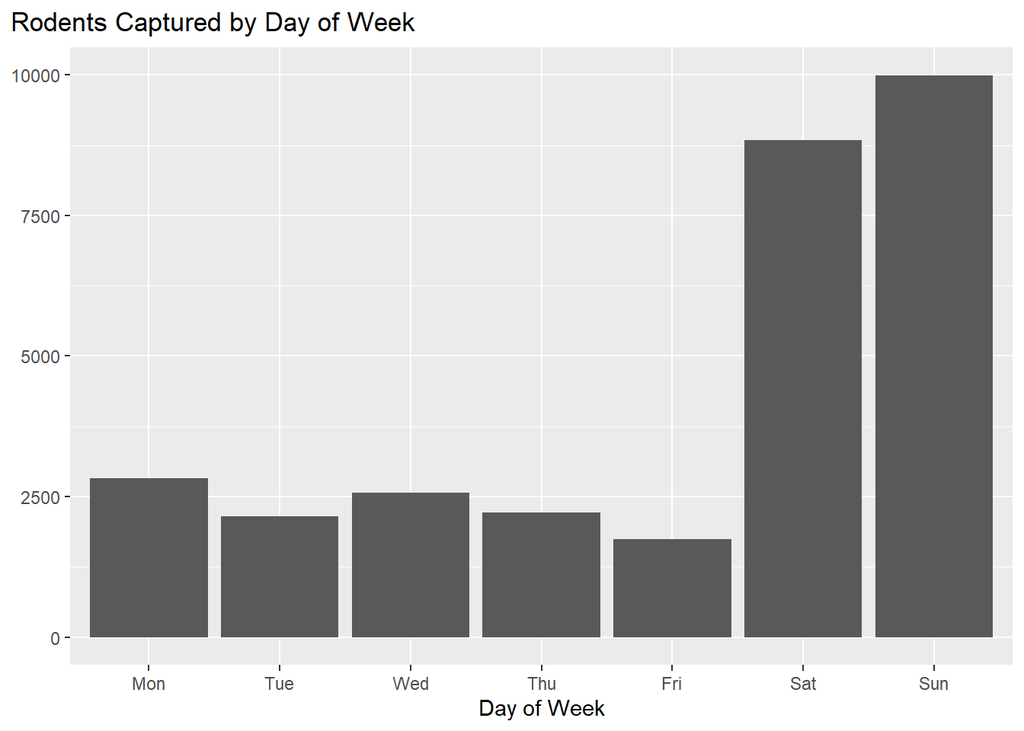

```r
day_order <- c("Mon", "Tue", "Wed", "Thu", "Fri", "Sat", "Sun")

ggplot(data = rodents_week,
       mapping = aes(
         x = fct_relevel(day_of_week, day_order),
         y = rodents_captured
        )
       ) +
  geom_col() +
  labs(x = "Day of Week",
       y = NULL,
       title = "Rodents Captured by Day of Week"
   ) +
  theme(
    plot.title.position = "plot"
  )
```

### 3. Collapse Monday through Friday into a `"Weekday"` level, and collapse Saturday and Sunday into a `"Weekend"` level. Plot the number of rodents captured between the two groups

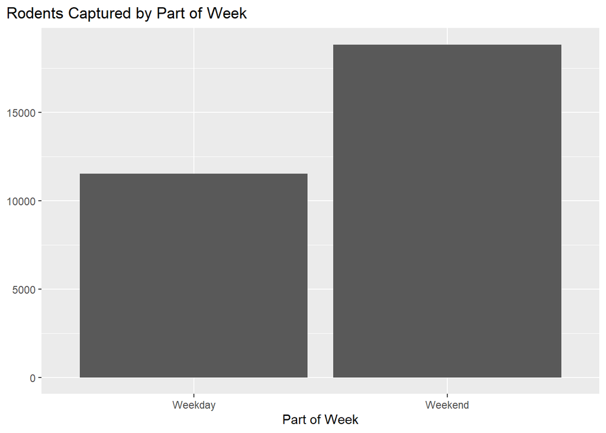

```r
rodents_week <- rodents_week |>
  mutate(
    day_of_week = fct_collapse(day_of_week,
      "Weekday" = c("Mon", "Tue", "Wed", "Thu", "Fri"),
      "Weekend" = c("Sat", "Sun")
      )
  )


ggplot(data = rodents_week,
       mapping = aes(
         x = day_of_week,
         y = rodents_captured
        )
       ) +
  geom_col() +
  labs(x = "Part of Week",
       y = NULL,
       title = "Rodents Captured by Part of Week"
   ) +
  theme(
    plot.title.position = "plot"
  )
```